# Advanced Business Analytics Project

Group Members

- Aryamaan Saha (s217084)
- Ananthalakshmi Nandakumar (s216911)

## Introduction

Coffee is an important beverage in the global economy. It is made from the seeds of the coffee plant, which are called coffee beans. Coffee plants require a certain temperature to grow and thrive. These temperatures are found mainly in South America, primarily Brazil who is responsible for a third of the world's coffee output. This is due to the rich soils and tropical climate in the country. About 70% of the coffee produced in Brazil is the Arabica coffee, from the *coffea arabica* plant, while the remaining is roughly made up of Robusta coffee, from the *coffea canephora* plant. Arabica is known to be more sugary, flavory with the perfect amount of caffeine, and is very likely the coffee you had this very morning. As caffeine and subsequently coffee consumption have grown in the last decades, the investment of coffee industries, both foreign and domestic, into these farms have risen.

The coffea arabica plant is requires an ideal temperature of 18 - 22 $^{\circ}$C, and can tolerate mean annual temperatures of 24 $^{\circ}$C. A high sensitivity to temperature and precipitation conditions renders arabica coffee production susceptible to increasing temperatures. With temperatures expected to rise globally, we're interested in studying the effects of these rising temperatures on coffee production, whether it's significant, if yes, exactly when will the production decline, etc. As coffee companies heavily invest and rely on these farms for their revenue, any such effects will have a direct implication in their business strategy and alter its dynamics.

Our study region consists of two states in Brazil - Minas Gerais and Rio Grande Do Sul. The state of Minas Gerais accounts nearly 50% of the country's coffee production, and is the main hub for Brazil's Arabica production (about 75% of the state's coffee output is *arabica*). Rio Grande Do Sul is a southern state with developing agriculture and rich lands. We're interested in the temperature forecasts of these regions.

```python
import pandas as pd
import numpy as np
import seaborn as sns
import matplotlib.pyplot as plt
sns.set()

import warnings
warnings.filterwarnings('ignore')
```

## Exploratory Data Analysis

We will use the [Berkeley Earth Surface Temperature](https://www.kaggle.com/berkeleyearth/climate-change-earth-surface-temperature-data?ref=hackernoon.com) dataset for our analysis.

```python
df = pd.read_csv('climchange/GlobalLandTemperaturesByState.csv', parse_dates=['dt'])
df
```

|  | dt | AverageTemperature | AverageTemperatureUncertainty | State | Country |
| --- | --- | --- | --- | --- | --- |
| 0 | 1855-05-01 | 25.544 | 1.171 | Acre | Brazil |
| 1 | 1855-06-01 | 24.228 | 1.103 | Acre | Brazil |
| 2 | 1855-07-01 | 24.371 | 1.044 | Acre | Brazil |
| 3 | 1855-08-01 | 25.427 | 1.073 | Acre | Brazil |
| 4 | 1855-09-01 | 25.675 | 1.014 | Acre | Brazil |
| ... | ... | ... | ... | ... | ... |
| 645670 | 2013-05-01 | 21.634 | 0.578 | Zhejiang | China |
| 645671 | 2013-06-01 | 24.679 | 0.596 | Zhejiang | China |
| 645672 | 2013-07-01 | 29.272 | 1.340 | Zhejiang | China |
| 645673 | 2013-08-01 | 29.202 | 0.869 | Zhejiang | China |
| 645674 | 2013-09-01 | NaN | NaN | Zhejiang | China |

645675 rows × 5 columns

# Minas Gerais

The average temperature data for each state in each country is available, along with the average uncertainty. For now, are interested in the average temperature data for the state of Minas Gerais, in Brazil.

```python
filt = df['State'] == 'Minas Gerais'
mg = df[filt]
mg = mg[['dt', 'AverageTemperature']]
mg.reset_index(inplace=True, drop=True)
# Let's also change the index to the date index.
mg.set_index('dt', inplace=True)
mg.head()
```

| dt | AverageTemperature |
| --- | --- |
| 1832-01-01 | 23.128 |
| 1832-02-01 | 23.588 |
| 1832-03-01 | 22.784 |
| 1832-04-01 | 20.959 |
| 1832-05-01 | 19.541 |

```python
mg.isnull().sum()
```

```
AverageTemperature    85
dtype: int64
```

Looks like there is some missing data. We could fill it in using some interpolation methods or we could remove it. In this case, let's us remove it.

```python
mg.dropna(inplace=True);
```

### Plotting the time series

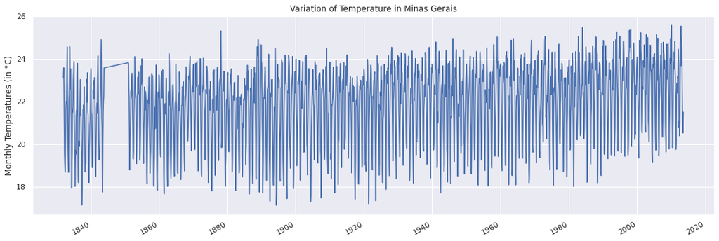

```python
mg['AverageTemperature'].plot( figsize=(18,6));
plt.xlabel('')
plt.ylabel(f'Monthly Temperatures (in {chr(176)}C)')
plt.title('Variation of Temperature in Minas Gerais')
plt.show()
```

The data points seem congested, but there's a visible upward trend. To better understand, let's visualize the annual average.

```python
mg['month'] = mg.index.month
mg['year'] = mg.index.year
mg.head()
```

| dt | AverageTemperature | month | year |
| --- | --- | --- | --- |
| 1832-01-01 | 23.128 | 1 | 1832 |
| 1832-02-01 | 23.588 | 2 | 1832 |
| 1832-03-01 | 22.784 | 3 | 1832 |
| 1832-04-01 | 20.959 | 4 | 1832 |
| 1832-05-01 | 19.541 | 5 | 1832 |

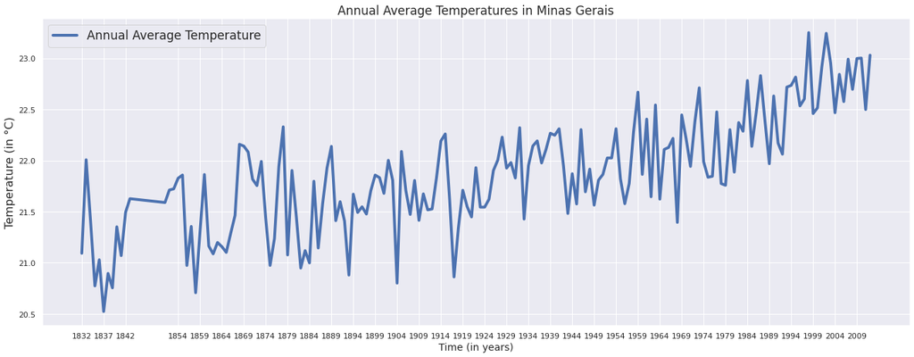

```python
annual = mg.drop(columns='month', axis=1).groupby('year').mean()[:-1]
annual.rename(columns={'AverageTemperature':'Annual Average Temperature'}, inplace=True)
annual[['Annual Average Temperature']].plot(figsize=(22,8), linewidth=4)
plt.title('Annual Average Temperatures in Minas Gerais', fontsize=17)
plt.xlabel('Time (in years)', fontsize=14)
plt.ylabel(f'Temperature (in {chr(176)}C)', fontsize=16)
plt.xticks([x for x in annual.index[::5]])
plt.legend(fontsize=17)
plt.show()
```

Clearly, there's an increasing trend. Since it is temperature data, we could also expect it to vary over seasons.

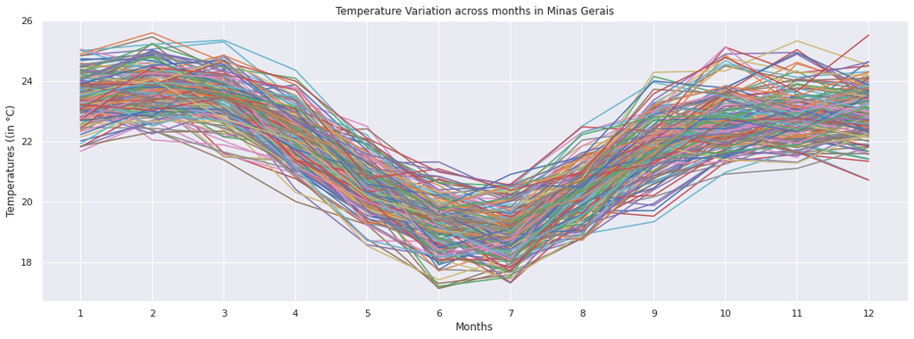

```python
pv = pd.pivot_table(mg, values='AverageTemperature', index=mg.index.month, columns=mg.index.year, aggfunc='mean')
pv.plot(figsize=(18,6))
plt.title('Temperature Variation across months in Minas Gerais')
plt.xlabel('Months')
plt.ylabel(f'Temperatures ((in {chr(176)}C)')
plt.xticks([x for x in range(1,13)])
plt.legend().remove()
plt.show()
```

Usually, the best way to visualize the trend and seasonality of a model is by decomposing it and viewing it in seperate plots.

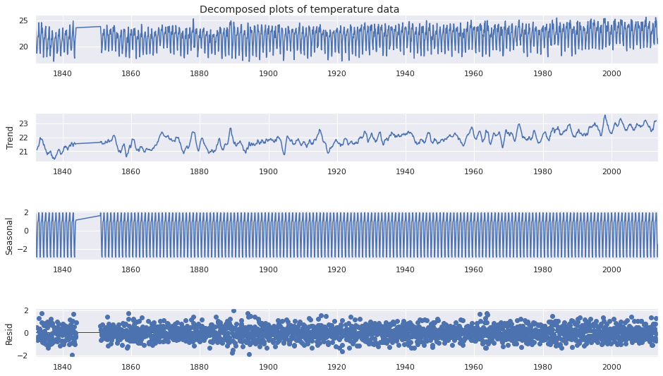

```python
from statsmodels.tsa.seasonal import seasonal_decompose
seasonal_decompose(mg[['AverageTemperature']], period=12).plot()
plt.gcf().set_size_inches((15,8))
plt.suptitle('Decomposed plots of temperature data')
plt.show()
```

## Modelling

We want to develop a model that fits into our time series data. To do this, we have to check if the time series is stationary, and if not, we must stationarize it as all standard time series models rely on this feature.

### Stationarity

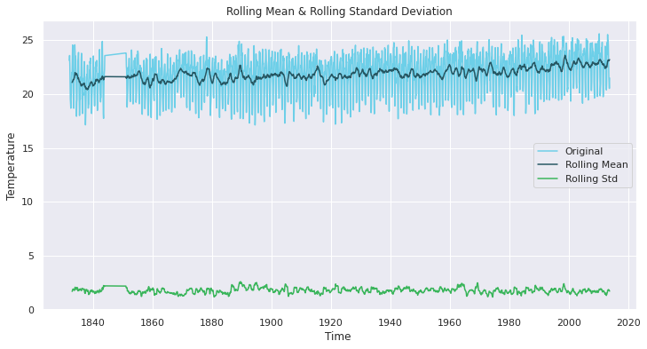

```python
plt.figure(figsize=(12, 6))
plt.plot(mg['AverageTemperature'], color='#6dcfe8',label='Original')
plt.plot(mg['AverageTemperature'].rolling(12).mean(), color='#265763', label='Rolling Mean')
plt.plot(mg['AverageTemperature'].rolling(12).std(), color='#3ab55b', label = 'Rolling Std')
plt.xlabel('Time ')
plt.ylabel('Temperature')
plt.title('Rolling Mean & Rolling Standard Deviation')
plt.legend(loc='best')
plt.show()
```

The variance of our data is stable, there seems to be no need of any log transformations.

```python
# Augmented Dickey-Fuller test
from statsmodels.tsa.stattools import adfuller

result = adfuller(mg['AverageTemperature'])
print('ADF Statistic: %f' % result[0])
print('p-value: %f' % result[1])
print('Critical Values:')
for key, value in result[4].items():
   print('\t%s: %.3f' % (key, value))
```

```
ADF Statistic: -3.580661
p-value: 0.006142
Critical Values:
	1%: -3.434
	5%: -2.863
	10%: -2.568
```

If we consider the significance level to be 0.05 then, for the above p-value < 0.05 result, we can say that the series is stationary.

```python
result = adfuller(mg['AverageTemperature'].diff(1).dropna())
print('ADF Statistic: %f' % result[0])
print('p-value: %f' % result[1])
print('Critical Values:')
for key, value in result[4].items():
   print('\t%s: %.3f' % (key, value))
```

```
ADF Statistic: -14.149400
p-value: 0.000000
Critical Values:
	1%: -3.434
	5%: -2.863
	10%: -2.568
```

Adding a first difference significantly reduced the p value and stationarized the series, it might be better to use that while developing our time series model.

### Autocorrelation

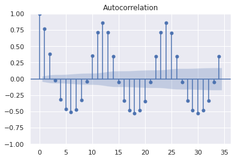

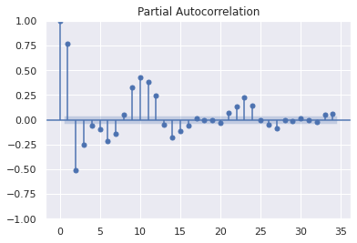

```python
from statsmodels.graphics.tsaplots import plot_acf, plot_pacf
plot_acf(mg['AverageTemperature']);
plot_pacf(mg['AverageTemperature']);
```

Let's look at the autocorrelation plots upon adding an annual seasonal difference.

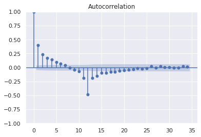

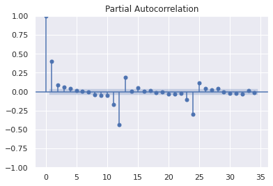

```python
plot_acf(mg['AverageTemperature'].diff(12).dropna());
plot_pacf(mg['AverageTemperature'].diff(12).dropna());
```

## SARIMA Model

We decided to use a seasonal ARIMA (SARIMA) model for fitting our time series. We chose 1856 months of time series data for our training set and the remaining (240) for the test set.

```python
from sklearn.metrics import mean_squared_error, r2_score
import statsmodels.api as sm

# Defining a root mean-squared error function
rmse = lambda x, y: np.sqrt(mean_squared_error(x,y))
test_size = 240
train_size = len(mg) - test_size
trainset = mg[['AverageTemperature']][:-test_size].copy()
testset = mg[['AverageTemperature']][-test_size:].copy()
```

```python
# We found these orders to be the best fit for the data
p, d, q = (1, 1, 0)
P, D, Q, S = (1, 1, 2, 12)
sarima = sm.tsa.statespace.SARIMAX(trainset, order=(p, d, q), seasonal_order=(P, D, Q, S),
                                    simple_differencing=0, enforce_stationarity=True, enforce_invertibility=False)
mfit = sarima.fit()

testpred = mfit.forecast(test_size)
testpred.index = testset.index

RSS = np.sqrt(sum(testpred.values-testset.values.reshape(-1))**2)/test_size
print(f'Root Squared Error of SARIMAX model(p,d,q)(p,d,q,s):' ,(p, d, q),(P, D, Q, S),':', round(RSS, 3),"\n")
print(mfit.summary())
```

```
Root Squared Error of SARIMAX model(p,d,q)(p,d,q,s): (1, 1, 0) (1, 1, 2, 12) : 0.073

                                        SARIMAX Results
===============================================================================================
Dep. Variable:                      AverageTemperature   No. Observations:                 1856
Model:             SARIMAX(1, 1, 0)x(1, 1, [1, 2], 12)   Log Likelihood               -1899.726
Date:                                 Wed, 11 May 2022   AIC                           3809.453
Time:                                         17:17:36   BIC                           3837.049
Sample:                                              0   HQIC                          3819.627
                                                - 1856
Covariance Type:                                   opg
==============================================================================
                 coef    std err          z      P>|z|      [0.025      0.975]
------------------------------------------------------------------------------
ar.L1         -0.3456      0.022    -15.422      0.000      -0.389      -0.302
ar.S.L12       0.8540      0.097      8.826      0.000       0.664       1.044
ma.S.L12      -1.7928      0.110    -16.255      0.000      -2.009      -1.577
ma.S.L24       0.7943      0.108      7.354      0.000       0.583       1.006
sigma2         0.4505      0.015     31.007      0.000       0.422       0.479
===================================================================================
Ljung-Box (L1) (Q):                  15.56   Jarque-Bera (JB):                 2.55
Prob(Q):                              0.00   Prob(JB):                         0.28
Heteroskedasticity (H):               1.08   Skew:                            -0.00
Prob(H) (two-sided):                  0.33   Kurtosis:                         3.18
===================================================================================

Warnings:
[1] Covariance matrix calculated using the outer product of gradients (complex-step).
```

The RMSE is low and the parameters are statistically significant!

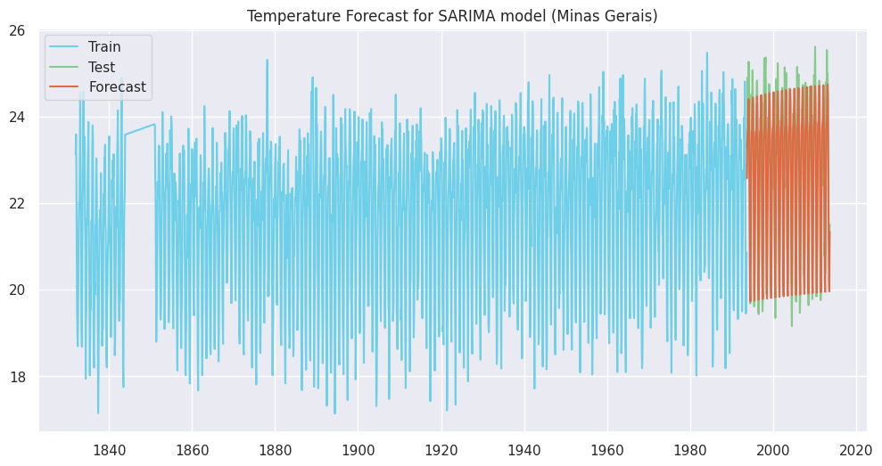

```python
plt.figure(figsize=(12,6), dpi=100)
plt.plot(trainset, color='#6dcfe8', label='Train')
plt.plot(testset, color='#45b549', label='Test', alpha=0.6)
plt.plot(testpred, color='#de6943', label='Forecast', alpha=1)
plt.legend(loc='upper left')
plt.title('Temperature Forecast for SARIMA model (Minas Gerais)')
plt.show()
```

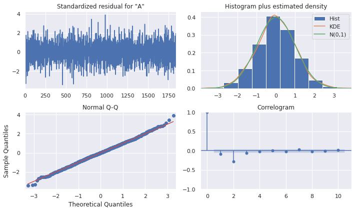

```python
mfit.plot_diagnostics(figsize=(10,6))
plt.tight_layout(pad=1)
plt.show()
```

### Evaluation on Test set

```python
print('RMSE:', rmse(testset, testpred))
print('R squared:', r2_score(testset, testpred))
```

```
RMSE: 0.6466033808727631
R squared: 0.8498191396983683
```

The chosen SARIMA model fits our data quite well. But can we do better?

## Stacked LSTM Model (Deep Learning)

Deep Learning models can learn complex patterns and features. In particular, LSTMs, a variant of RNNs, are good at time series modelling as they can account for the sequential nature of a time series. We decided to use a stacked LSTM model, feeding in the target, lagged features and a time dummy variable, in order to predict against the target, which is the average temperature. The good thing about deep learning models is that we don't need to provide any terms for stationarity or seasonality, it automatically detects the complex patterns in the data.

```python
from tensorflow.keras.models import Sequential
from tensorflow.keras.layers import LSTM
from tensorflow.keras.layers import Dense
from sklearn.preprocessing import MinMaxScaler
```

```python
deepmg = mg[['AverageTemperature']].copy()
deepmg['lag 3'] = deepmg['AverageTemperature'].shift(3) # lag of 3 months
deepmg['lag 6'] = deepmg['AverageTemperature'].shift(6) # lag of 6 months
deepmg['lag 9'] = deepmg['AverageTemperature'].shift(9) # lag of 9 months
deepmg = deepmg.dropna()
deepmg['dummy'] = np.arange(1, len(deepmg)+1)
deepmg
```

| dt | AverageTemperature | lag 3 | lag 6 | lag 9 | dummy |
| --- | --- | --- | --- | --- | --- |
| 1832-10-01 | 21.624 | 18.688 | 20.959 | 23.128 | 1 |
| 1832-11-01 | 22.012 | 19.280 | 19.541 | 23.588 | 2 |
| 1832-12-01 | 21.875 | 20.605 | 19.033 | 22.784 | 3 |
| 1833-01-01 | 23.284 | 21.624 | 18.688 | 20.959 | 4 |
| 1833-02-01 | 24.559 | 22.012 | 19.280 | 19.541 | 5 |
| ... | ... | ... | ... | ... | ... |
| 2013-04-01 | 22.697 | 24.053 | 24.796 | 20.393 | 2083 |
| 2013-05-01 | 21.581 | 24.989 | 23.677 | 20.994 | 2084 |
| 2013-06-01 | 21.027 | 24.512 | 25.535 | 23.593 | 2085 |
| 2013-07-01 | 20.529 | 22.697 | 24.053 | 24.796 | 2086 |
| 2013-08-01 | 21.501 | 21.581 | 24.989 | 23.677 | 2087 |

2087 rows × 5 columns

```python
# Function to generate sequence data i.e. a sliding window
def sliding_windows(data, seq_length):
    x, y = [], []
    for i in range(len(data)-seq_length):
        x_ = data[i:i + seq_length]
        y_ = data[i + seq_length]
        x.append(x_)
        y.append(y_)

    return np.array(x),np.array(y)
```

```python
# LSTMs are sensitive to the input range, and learns best when there's a standard scaling of data
sc = MinMaxScaler()
sc_d = MinMaxScaler()


seq_length = 24 # Sequence length of 24 months

scdata_avg = sc.fit_transform(deepmg[['AverageTemperature']])
scdata_l3 = sc.transform(deepmg[['lag 3']])
scdata_l6 = sc.transform(deepmg[['lag 6']])
scdata_l9 = sc.transform(deepmg[['lag 9']])
scdata_d = sc_d.fit_transform(deepmg[['dummy']])

x_avg, y_avg = sliding_windows(scdata_avg, seq_length)
x_lag3, y_lag3 = sliding_windows(scdata_l3, seq_length)
x_lag6, y_lag6 = sliding_windows(scdata_l6, seq_length)
x_lag9, y_lag9 = sliding_windows(scdata_l9, seq_length)

x_d, y_d = sliding_windows(scdata_d, seq_length)


X_train_mg = np.concatenate((x_avg, x_d, x_lag3, x_lag6, x_lag9), axis=2)
y_train_mg = y_avg.reshape(-1,1)
print(X_train_mg.shape, y_train_mg.shape)
```

```
(2063, 24, 5) (2063, 1)
```

We decided to train the stacked LSTM model on the entire dataset, as we want the model to learn even on the last few years of data (which we would have usually excluded to include in the test set, thereby leading to the model having no information on it)

```python
n_features = 5

model = Sequential()
model.add(LSTM(128, activation='relu',return_sequences=True, input_shape=(seq_length, n_features)))
model.add(LSTM(64, activation='relu', return_sequences=False))
model.add(Dense(32))
model.add(Dense(1))
model.compile(optimizer='adam', loss='mse')

model.fit(X_train_mg, y_train_mg, epochs=100, verbose=1)
```

```
<tensorflow.python.keras.callbacks.History at 0x7f453c488bd0>
```

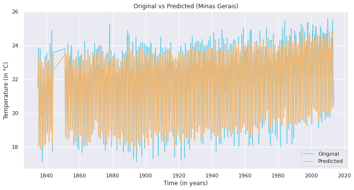

```python
y_orig_mg = pd.Series(sc.inverse_transform(y_train_mg).squeeze(), index=deepmg.index[seq_length:])
y_pred_mg = pd.Series(sc.inverse_transform(model.predict(X_train_mg)).squeeze(), index=deepmg.index[seq_length:])
plt.figure(figsize=(12,6))
plt.plot(y_orig_mg, color='#6dcfe8', label='Original')
plt.plot(y_pred_mg, color='#f2b56f', label='Predicted')
plt.legend()
plt.title('Original vs Predicted (Minas Gerais)')
plt.xlabel('Time (in years)')
plt.ylabel(f'Temperature (in {chr(176)}C)')
plt.show()
```

```python
print('RMSE:', rmse(sc.inverse_transform(y_train_mg), sc.inverse_transform(model.predict(X_train_mg))))
print('R squared:', r2_score(sc.inverse_transform(y_train_mg), sc.inverse_transform(model.predict(X_train_mg))))
```

```
RMSE: 0.582722961574713
R squared: 0.8930200351119083
```

Our stacked LSTM model fits the data very well, even better than the SARIMA model!

Note: The comparison isn't entirely fair as the RMSE and R squared values are being calculated for the training set here, as opposed to using the test set in the SARIMA model. Nonetheless we're looking for a model that fits our data the best.

## Predicting the Future with Deep Learning

Using our trained LSTM model, we will now predict the future temperatures (uptil 2080). We could have also used the SARIMA model results to forecast the future temperatures, but we chose the Deep learning model.

```python
import datetime
import monthdelta

fc_mg = deepmg[-seq_length:].copy()
j = fc_mg[-seq_length:]['dummy'][-1]
for i in range(67*12+4):
    inp1 = sc.transform(fc_mg[-seq_length:].values[:, 0].reshape(-1,1).astype(np.float32))
    inp2 = sc.transform(fc_mg[-seq_length:].values[:, 1].reshape(-1,1).astype(np.float32))
    inp3 = sc.transform(fc_mg[-seq_length:].values[:, 2].reshape(-1,1).astype(np.float32))
    inp4 = sc.transform(fc_mg[-seq_length:].values[:, 3].reshape(-1,1).astype(np.float32))
    td = sc_d.transform(fc_mg[-seq_length:].values[:, 4].reshape(-1,1).astype(np.float32))



    inp = np.stack((inp1, td, inp2, inp3, inp4), axis=2).reshape(1, -1, n_features)
    o = model.predict(inp)
    o = sc.inverse_transform(o)
    j = j+1
    fc_mg.loc[fc_mg.index[-1] + monthdelta.monthdelta(1)] = [o.squeeze(),
                                                     fc_mg['AverageTemperature'][-3],
                                                     fc_mg['AverageTemperature'][-6],
                                                     fc_mg['AverageTemperature'][-9],
                                                     j]
```

Let's concatenate the forecast to the original data to get the complete time series.

```python
full_mg = pd.DataFrame(pd.concat([mg['AverageTemperature'].astype(float), fc_mg['AverageTemperature'][seq_length:].astype(float)], axis=0))
```

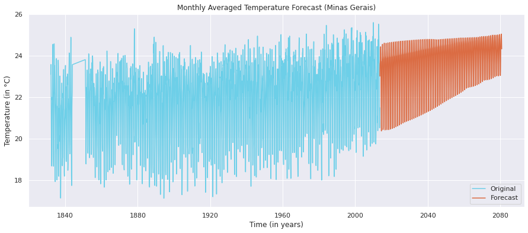

```python
plt.figure(figsize=(15,6))
plt.plot(mg['AverageTemperature'], color='#6dcfe8', label='Original')
plt.plot(fc_mg['AverageTemperature'][seq_length:], color='#db6b42', label='Forecast')
plt.legend()
plt.title('Monthly Averaged Temperature Forecast (Minas Gerais)')
plt.xlabel('Time (in years)')
plt.ylabel(f'Temperature (in {chr(176)}C)')
plt.show()
```

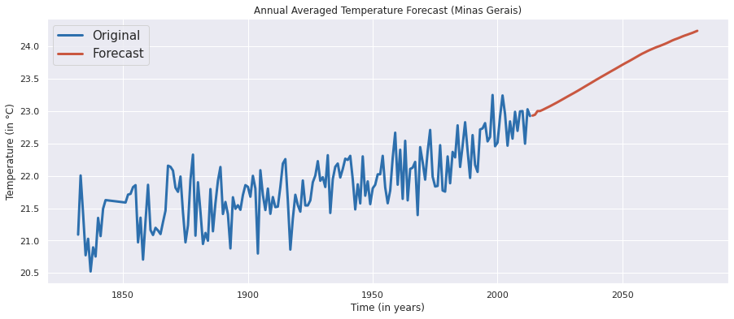

```python
full_mg['year'] = full_mg.index.year
ax = full_mg[:'2013'].groupby('year').mean().plot(figsize=(15,6), color='#2d6fad', linewidth=3)
full_mg['2014':].groupby('year').mean().plot(figsize=(15,6), color='#c95740', linewidth=3, ax=ax)
plt.legend(['Original', 'Forecast'], fontsize=15)
plt.xlabel('Time (in years)')
plt.ylabel(f'Temperature (in {chr(176)}C)')
plt.title('Annual Averaged Temperature Forecast (Minas Gerais)')
plt.show()
```

# Rio Grande Do Sul

Now we shift our focus to the study region of Rio Grande Do Sul.

```python
filt = df['State'] == 'Rio Grande Do Sul'
rio = df[filt]
rio = rio[['dt', 'AverageTemperature']]
rio.reset_index(inplace=True, drop=True)
rio.set_index('dt', inplace=True)
rio.head()
```

| dt | AverageTemperature |
| --- | --- |
| 1832-01-01 | 23.675 |
| 1832-02-01 | 23.276 |
| 1832-03-01 | 21.666 |
| 1832-04-01 | 18.156 |
| 1832-05-01 | 14.720 |

We repeat the same EDA on this state.

```python
rio.isnull().sum()
```

```
AverageTemperature    85
dtype: int64
```

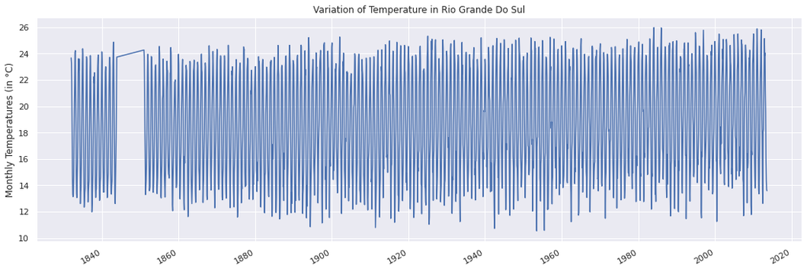

```python
rio.dropna(inplace=True);
rio['AverageTemperature'].plot( figsize=(18,6));
plt.xlabel('')
plt.ylabel(f'Monthly Temperatures (in {chr(176)}C)')
plt.title('Variation of Temperature in Rio Grande Do Sul')
plt.show()
```

```python
rio['month'] = rio.index.month
rio['year'] = rio.index.year
rio.head()
```

| dt | AverageTemperature | month | year |
| --- | --- | --- | --- |
| 1832-01-01 | 23.675 | 1 | 1832 |
| 1832-02-01 | 23.276 | 2 | 1832 |
| 1832-03-01 | 21.666 | 3 | 1832 |
| 1832-04-01 | 18.156 | 4 | 1832 |
| 1832-05-01 | 14.720 | 5 | 1832 |

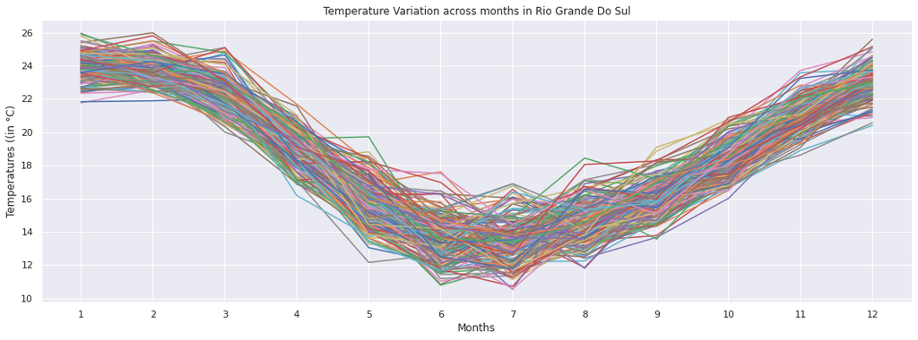

```python
pv = pd.pivot_table(rio, values='AverageTemperature', index=rio.index.month, columns=rio.index.year, aggfunc='mean')
pv.plot(figsize=(18,6))
plt.title('Temperature Variation across months in Rio Grande Do Sul')
plt.xlabel('Months')
plt.ylabel(f'Temperatures ((in {chr(176)}C)')
plt.xticks([x for x in range(1,13)])
plt.legend().remove()
plt.show()
```

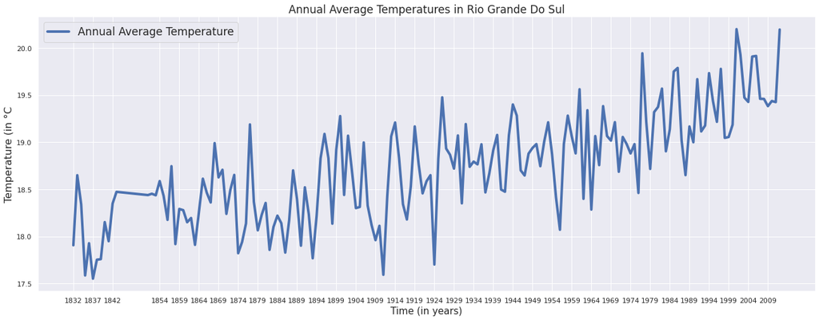

```python
annual = rio.drop(columns='month', axis=1).groupby('year').mean()[:-1]
annual.rename(columns={'AverageTemperature':'Annual Average Temperature'}, inplace=True)
annual[['Annual Average Temperature']].plot(figsize=(22,8), linewidth=4)
plt.title('Annual Average Temperatures in Rio Grande Do Sul', fontsize=17)
plt.xlabel('Time (in years)', fontsize=15)
plt.ylabel(f'Temperature (in {chr(176)}C', fontsize=16)
plt.xticks([x for x in annual.index[::5]])
plt.legend(fontsize=17)
plt.show()
```

## Modelling

The stacked LSTM model gave us good results for the temperature data previously. We skipped the SARIMA model for Rio Grande Do Sul, and directly used a deep learning model for prediction. We don't need to analyse the stationarity or autocorrelations of the time series this time, as we're using a deep learning model.

```python
deeprio = rio[['AverageTemperature']].copy()
deeprio['lag 3'] = deeprio['AverageTemperature'].shift(3)
deeprio['lag 6'] = deeprio['AverageTemperature'].shift(6)
deeprio['lag 9'] = deeprio['AverageTemperature'].shift(9)
deeprio = deeprio.dropna()
deeprio['dummy'] = np.arange(1, len(deeprio)+1)
deeprio
```

| dt | AverageTemperature | lag 3 | lag 6 | lag 9 | dummy |
| --- | --- | --- | --- | --- | --- |
| 1832-10-01 | 17.459 | 13.131 | 18.156 | 23.675 | 1 |
| 1832-11-01 | 19.988 | 13.193 | 14.720 | 23.276 | 2 |
| 1832-12-01 | 21.698 | 14.612 | 13.308 | 21.666 | 3 |
| 1833-01-01 | 24.084 | 17.459 | 13.131 | 18.156 | 4 |
| 1833-02-01 | 24.231 | 19.988 | 13.193 | 14.720 | 5 |
| ... | ... | ... | ... | ... | ... |
| 2013-04-01 | 19.556 | 23.848 | 20.617 | 12.621 | 2083 |
| 2013-05-01 | 16.040 | 24.041 | 23.322 | 18.052 | 2084 |
| 2013-06-01 | 14.366 | 21.263 | 25.142 | 18.267 | 2085 |
| 2013-07-01 | 13.684 | 19.556 | 23.848 | 20.617 | 2086 |
| 2013-08-01 | 13.582 | 16.040 | 24.041 | 23.322 | 2087 |

2087 rows × 5 columns

```python
sc = MinMaxScaler()
sc_d = MinMaxScaler()

seq_length = 24 # Sequence length of 24 months

scdata_avg = sc.fit_transform(deeprio[['AverageTemperature']])
scdata_l3 = sc.transform(deeprio[['lag 3']])
scdata_l6 = sc.transform(deeprio[['lag 6']])
scdata_l9 = sc.transform(deeprio[['lag 9']])
scdata_d = sc_d.fit_transform(deeprio[['dummy']])

x_avg, y_avg = sliding_windows(scdata_avg, seq_length)
x_lag3, y_lag3 = sliding_windows(scdata_l3, seq_length)
x_lag6, y_lag6 = sliding_windows(scdata_l6, seq_length)
x_lag9, y_lag9 = sliding_windows(scdata_l9, seq_length)
x_d, y_d = sliding_windows(scdata_d, seq_length)


X_train_rio = np.concatenate((x_avg, x_d, x_lag3, x_lag6, x_lag9), axis=2)
y_train_rio = y_avg.reshape(-1,1)
print(X_train_rio.shape, y_train_rio.shape)
```

```
(2063, 24, 5) (2063, 1)
```

```python
n_features = 5

model_rio = Sequential()
model_rio.add(LSTM(128, activation='relu',return_sequences=True, input_shape=(seq_length, n_features)))
model_rio.add(LSTM(64, activation='relu', return_sequences=False))
model_rio.add(Dense(32))
model_rio.add(Dense(1))
model_rio.compile(optimizer='adam', loss='mse')

model_rio.fit(X_train_rio, y_train_rio, epochs=200, verbose=1)
```

```
<tensorflow.python.keras.callbacks.History at 0x7f452412ea90>
```

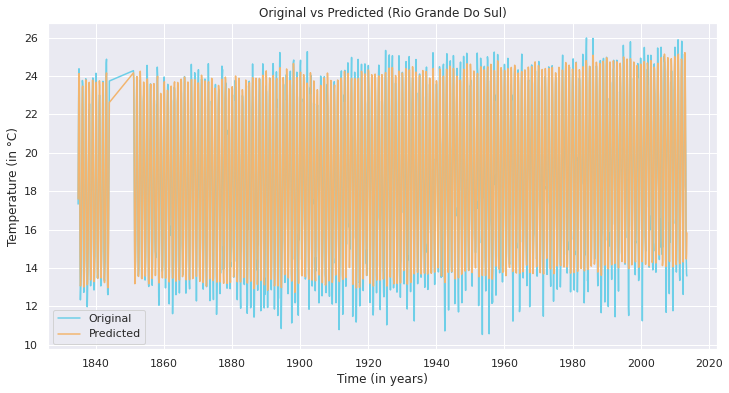

```python
y_orig_rio = pd.Series(sc.inverse_transform(y_train_rio).squeeze(), index=deeprio.index[seq_length:])
y_pred_rio = pd.Series(sc.inverse_transform(model_rio.predict(X_train_rio)).squeeze(), index=deeprio.index[seq_length:])
plt.figure(figsize=(12,6))
plt.plot(y_orig_rio, color='#6dcfe8', label='Original')
plt.plot(y_pred_rio, color='#f2b56f', label='Predicted')
plt.legend()
plt.title('Original vs Predicted (Rio Grande Do Sul)')
plt.xlabel('Time (in years)')
plt.ylabel(f'Temperature (in {chr(176)}C)')
plt.show()
```

```python
print('RMSE:', rmse(sc.inverse_transform(y_train_rio), sc.inverse_transform(model_rio.predict(X_train_rio))))
print('R squared:', r2_score(sc.inverse_transform(y_train_rio), sc.inverse_transform(model_rio.predict(X_train_rio))))
```

```
RMSE: 0.9715552036535133
R squared: 0.940557314922238
```

## Future Prediction

Just as before, let's forecast the temperatures uptil 2080.

```python
fc_rio = deeprio[-seq_length:].copy()
j = fc_rio[-seq_length:]['dummy'][-1]
for i in range(67*12+4):
    inp1 = sc.transform(fc_rio[-seq_length:].values[:, 0].reshape(-1,1).astype(np.float32))
    inp2 = sc.transform(fc_rio[-seq_length:].values[:, 1].reshape(-1,1).astype(np.float32))
    inp3 = sc.transform(fc_rio[-seq_length:].values[:, 2].reshape(-1,1).astype(np.float32))
    inp4 = sc.transform(fc_rio[-seq_length:].values[:, 3].reshape(-1,1).astype(np.float32))
    td = sc_d.transform(fc_rio[-seq_length:].values[:, 4].reshape(-1,1).astype(np.float32))

    inp = np.stack((inp1, td, inp2, inp3, inp4), axis=2).reshape(1, -1, n_features)
    o = model_rio.predict(inp)
    o = sc.inverse_transform(o)
    j = j+1
    fc_rio.loc[fc_rio.index[-1] + monthdelta.monthdelta(1)] = [o.squeeze(),
                                                     fc_rio['AverageTemperature'][-3],
                                                     fc_rio['AverageTemperature'][-6],
                                                     fc_rio['AverageTemperature'][-9],
                                                     j]
```

```python
full_rio = pd.DataFrame(pd.concat([rio['AverageTemperature'].astype(float), fc_rio['AverageTemperature'][seq_length:].astype(float)], axis=0))
```

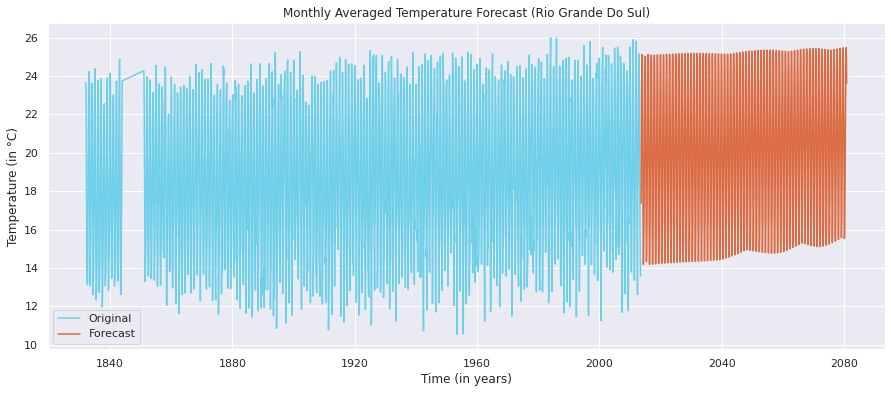

```python
plt.figure(figsize=(15,6))
plt.plot(rio['AverageTemperature'], color='#6dcfe8', label='Original')
plt.plot(fc_rio['AverageTemperature'][seq_length:], color='#db6b42', label='Forecast')
plt.legend()
plt.title('Monthly Averaged Temperature Forecast (Rio Grande Do Sul)')
plt.xlabel('Time (in years)')
plt.ylabel(f'Temperature (in {chr(176)}C)')
plt.show()
```

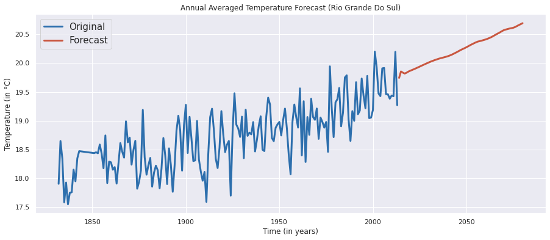

```python
full_rio['year'] = full_rio.index.year
ax = full_rio[:'2013'].groupby('year').mean().plot(figsize=(15,6), color='#2d6fad', linewidth=3)
full_rio['2014':].groupby('year').mean().plot(figsize=(15,6), color='#c95740', linewidth=3, ax=ax)
plt.legend(['Original', 'Forecast'], fontsize=15)
plt.xlabel('Time (in years)')
plt.ylabel(f'Temperature (in {chr(176)}C)')
plt.title('Annual Averaged Temperature Forecast (Rio Grande Do Sul)')
plt.show()
```

## Comparison

We used the results from the stacked LSTM model to draw comparisons between the temperature forecasts of Minas Gerais and Rio Grande Do Sul

```python
full_mg.groupby('year').mean()['AverageTemperature'].loc['2060':]
```

```
year
2060    23.928814
2061    23.946813
2062    23.963336
2063    23.980033
2064    23.995351
2065    24.009172
2066    24.024352
2067    24.040080
2068    24.057059
2069    24.075529
2070    24.093854
2071    24.109704
2072    24.123479
2073    24.138862
2074    24.155237
2075    24.169886
2076    24.182980
2077    24.197202
2078    24.210706
2079    24.226548
2080    24.242608
Name: AverageTemperature, dtype: float64
```

```python
full_rio.groupby('year').mean()['AverageTemperature'].loc['2060':]
```

```
year
2060    20.406950
2061    20.418209
2062    20.431434
2063    20.445463
2064    20.462283
2065    20.480939
2066    20.499524
2067    20.516770
2068    20.534536
2069    20.554308
2070    20.570804
2071    20.581528
2072    20.589780
2073    20.598640
2074    20.605289
2075    20.612439
2076    20.624872
2077    20.641943
2078    20.659659
2079    20.674910
2080    20.691626
Name: AverageTemperature, dtype: float64
```

```python
print(f'Avg increase in temperature every year in Minas Gerais:', round(full_mg.groupby('year').mean()['AverageTemperature'].loc['2014':].diff(1).mean(), 4))
print(f'Avg increase in temperature every year in Rio Grande Do Sul:', round(full_rio.groupby('year').mean()['AverageTemperature'].loc['2014':].diff(1).mean(), 4))
```

```
Avg increase in temperature every year in Minas Gerais: 0.0199
Avg increase in temperature every year in Rio Grande Do Sul: 0.0144
```

We observe that the average monthly temperature of Minas Gerais is exceeding 24 $^\circ$C in 2065, and is overall an increasing trend, which is in line with the historical data. It is projected to reach 24.25 $^\circ$C in 2080. The temperature increases $\sim$ 0.02 $^\circ$C every year in Minas Gerais, while it is $\sim$ 0.014 $^\circ$C in Rio Grande Do Sul. The average temperature in Rio Grande Do Sul in 2065 is $\sim$ 20.48 $^\circ$C and is projected to reach 20.7 $^\circ$C in 2080.

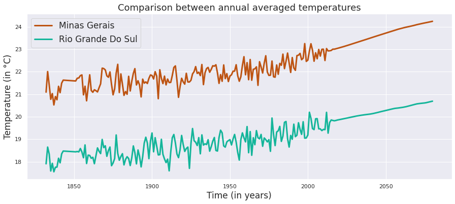

```python
plt.figure(figsize=(15,6))
plt.plot(full_mg.groupby('year').mean()['AverageTemperature'], label='Minas Gerais', lw=3, color='#bd5413')
plt.plot(full_rio.groupby('year').mean()['AverageTemperature'], label='Rio Grande Do Sul', lw=3, color='#14b59a')
plt.title('Comparison between annual averaged temperatures', fontsize=18)
plt.ylabel(f'Temperature (in {chr(176)}C)', fontsize=17)
plt.xlabel('Time (in years)', fontsize=17)
plt.legend(fontsize=17)
# plt.savefig('comparison_annual_avg.png')
plt.xlim(xlim)
plt.show()
```

# Conclusion

Our analysis suggests that there will be an impact on *Arabica* coffee production in Minas Gerais. The mean annual temperature is expected to exceed 24 $^\circ$C in 2065, beyond which *Arabica* production will reduce, as the lands become unsuitable for growing the plant. If other factors such as precipitation and probability of natural disasters are taken into account, this number may even be lower. The average yearly increase in temperature in Minas Gerais is around 0.02 $^\circ$C, which could be dangerous as higher temperatures also aid the proliferation of pests.

However, the state of Rio Grande Do Sul has rich agricultural land, and is at fairly low climate risk. The average temperatures is expected to reach only around 20.5 $^\circ$C in 2065, which is perfect for *Arabica* coffee production. The average yearly increase in temperature is only 0.014 $^\circ$C. Coffee businesses could consider investing in developing agricultural infrastructure for *arabica* production in this state, switching over from their investments in Minas Gerais.

Another possible solution could be investing in *Robusta* coffee production in Minas Gerais. *Robusta* , while not as popular, is more robust to climate change and pests, requiring about 24 - 30 $^\circ$C. Continuing to invest in *arabica* production simply may not be sustainable in the long run in Minas Gerais.

# References

https://www.climate.gov/news-features/climate-and/climate-coffee  
http://www.coffeeresearch.org/agriculture/environment.htm  
https://en.wikipedia.org/wiki/Coffee_production_in_Brazil  
https://journals.plos.org/plosone/article?id=10.1371/journal.pone.0219742  
https://perfectdailygrind.com/2021/08/a-guide-to-roasting-robusta-coffee/